# Class 24

Tobias Gerstenberg

March 6th, 2025

# 24 Bayesian data analysis 3

## 24.2 Load packages and set plotting theme

```r
library("knitr")       # for knitting RMarkdown
library("kableExtra")  # for making nice tables
library("janitor")     # for cleaning column names
library("tidybayes")   # tidying up results from Bayesian models
library("brms")        # Bayesian regression models with Stan
library("patchwork")   # for making figure panels
library("GGally")      # for pairs plot
library("broom.mixed") # for tidy lmer results
library("bayesplot")   # for visualization of Bayesian model fits
library("modelr")      # for modeling functions
library("lme4")        # for linear mixed effects models
library("afex")        # for ANOVAs
library("car")         # for ANOVAs
library("emmeans")     # for linear contrasts
library("ggeffects")   # for help with logistic regressions
library("titanic")     # titanic dataset
library("gganimate")   # for animations
library("parameters")  # for getting parameters
library("transformr")  # for gganimate
library("rstanarm")    # for Bayesian models
library("ggrepel")     # for labels in ggplots
library("scales")      # for percent y-axis
library("tidyverse")   # for wrangling, plotting, etc.
```

```r
theme_set(theme_classic() + #set the theme
            theme(text = element_text(size = 20))) #set the default text size

# set rstan options
rstan::rstan_options(auto_write = TRUE)
options(mc.cores = parallel::detectCores())

opts_chunk$set(comment = "",
               fig.show = "hold")
```

## 24.3 Evidence for the null hypothesis

See [this tutorial](https://mvuorre.github.io/posts/2017-03-21-bayes-factors-with-brms/) and this paper (Wagenmakers et al. 2010) for more information.

### 24.3.1 Bayes factor

#### 24.3.1.1 Fit the model

- Define a binomial model
- Give a uniform prior `beta(1, 1)`
- Get samples from the prior

```r
df.null = tibble(s = 6, k = 10)

fit.brm_bayes = brm(formula = s | trials(k) ~ 0 + Intercept,
                    family = binomial(link = "identity"),
                    prior = set_prior(prior = "beta(1, 1)",
                                      class = "b",
                                      lb = 0,
                                      ub = 1),
                    data = df.null,
                    sample_prior = TRUE,
                    cores = 4,
                    file = "cache/brm_bayes")
```

#### 24.3.1.2 Visualize the results

Visualize the prior and posterior samples:

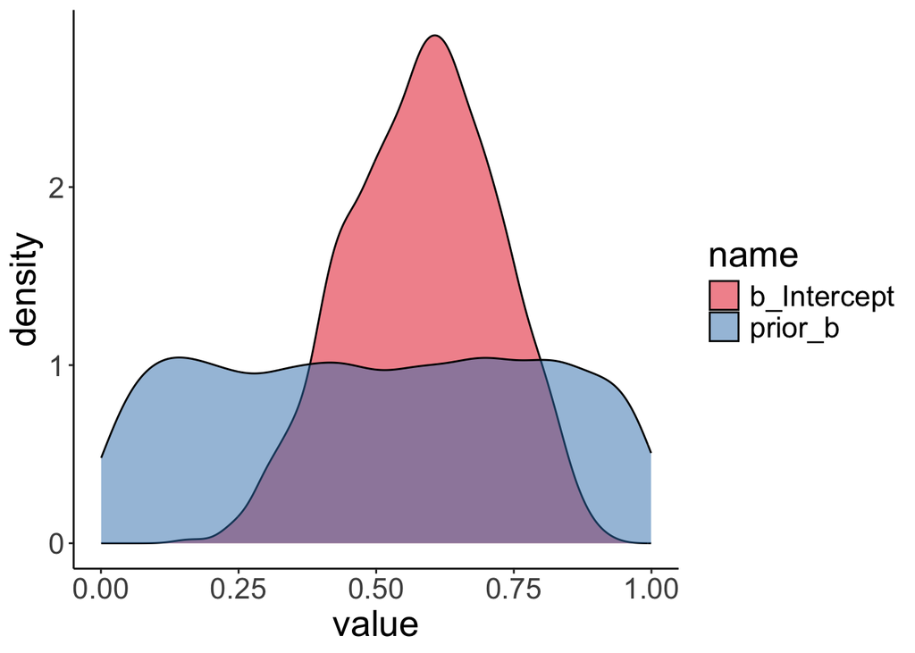

```r
fit.brm_bayes %>%
  as_draws_df(variable = "[b]",
              regex = T) %>%
  pivot_longer(cols = -contains(".")) %>%
  ggplot(mapping = aes(x = value,
                       fill = name)) +
  geom_density(alpha = 0.5) +
  scale_fill_brewer(palette = "Set1")
```

```r
fit.brm_bayes %>%
  as_draws_df(variable = "[b]",
              regex = T)
```

```
# A draws_df: 1000 iterations, 4 chains, and 2 variables
   b_Intercept prior_b
1         0.48    0.88
2         0.48    0.40
3         0.39    0.74
4         0.40    0.15
5         0.40    0.94
6         0.45    0.88
7         0.45    0.21
8         0.46    0.81
9         0.39    0.52
10        0.74    0.23
# ... with 3990 more draws
# ... hidden reserved variables {'.chain', '.iteration', '.draw'}
```

We test the H0: $\theta = 0.5$ versus the H1: $\theta \neq 0.5$ using the Savage-Dickey Method, according to which we can compute the Bayes factor like so:

$BF_{01} = \frac{p(D|H_0)}{p(D|H_1)} = \frac{p(\theta = 0.5|D, H_1)}{p(\theta = 0.5|H_1)}$

```r
fit.brm_bayes %>%
  hypothesis(hypothesis = "Intercept = 0.5")
```

```
Hypothesis Tests for class b:
             Hypothesis Estimate Est.Error CI.Lower CI.Upper Evid.Ratio
1 (Intercept)-(0.5) = 0     0.08      0.13    -0.19     0.33       2.22
  Post.Prob Star
1      0.69
---
'CI': 90%-CI for one-sided and 95%-CI for two-sided hypotheses.
'*': For one-sided hypotheses, the posterior probability exceeds 95%;
for two-sided hypotheses, the value tested against lies outside the 95%-CI.
Posterior probabilities of point hypotheses assume equal prior probabilities.
```

The result shows that the evidence ratio is in favor of the H0 with $BF_{01} = 2.22$. This means that H0 is 2.2 more likely than H1 given the data.

### 24.3.2 LOO

Another way to test different models is to compare them via approximate leave-one-out cross-validation.

```r
set.seed(1)
df.loo = tibble(x = rnorm(n = 50),
                y = rnorm(n = 50))

# visualize
ggplot(data = df.loo,
       mapping = aes(x = x,
                     y = y)) +
  geom_point()

# fit the frequentist model
fit.lm_loo = lm(formula = y ~ 1 + x,
                data = df.loo)

fit.lm_loo %>%
  summary()
```

```
Call:
lm(formula = y ~ 1 + x, data = df.loo)

Residuals:
     Min       1Q   Median       3Q      Max
-1.92760 -0.66898 -0.00225  0.48768  2.34858

Coefficients:
            Estimate Std. Error t value Pr(>|t|)
(Intercept)  0.12190    0.13935   0.875    0.386
x           -0.04555    0.16807  -0.271    0.788

Residual standard error: 0.9781 on 48 degrees of freedom
Multiple R-squared:  0.001528,  Adjusted R-squared:  -0.01927
F-statistic: 0.07345 on 1 and 48 DF,  p-value: 0.7875
```

```r
# fit and compare bayesian models
fit.brm_loo1 = brm(formula = y ~ 1,
                   data = df.loo,
                   seed = 1,
                   file = "cache/brm_loo1")

fit.brm_loo2 = brm(formula = y ~ 1 + x,
                   data = df.loo,
                   seed = 1,
                   file = "cache/brm_loo2")

fit.brm_loo1 = add_criterion(fit.brm_loo1,
                             criterion = "loo",
                             file = "cache/brm_loo1")

fit.brm_loo2 = add_criterion(fit.brm_loo2,
                             criterion = "loo",
                             file = "cache/brm_loo2")

loo_compare(fit.brm_loo1, fit.brm_loo2)
```

```
             elpd_diff se_diff
fit.brm_loo1  0.0       0.0
fit.brm_loo2 -1.1       0.5
```

```r
model_weights(fit.brm_loo1, fit.brm_loo2)
```

```
fit.brm_loo1 fit.brm_loo2
9.999989e-01 1.053955e-06
```

[figure not shown]

## 24.4 Dealing with heteroscedasticity

Let’s generate some fake developmental data where the variance in the data is greatest for young children, smaller for older children, and even smaller for adults:

```r
# make example reproducible
set.seed(1)

df.variance = tibble(group = rep(c("3yo", "5yo", "adults"), each = 20),
                     response = rnorm(n = 60,
                                      mean = rep(c(0, 5, 8), each = 20),
                                      sd = rep(c(3, 1.5, 0.3), each = 20)))
```

### 24.4.1 Visualize the data

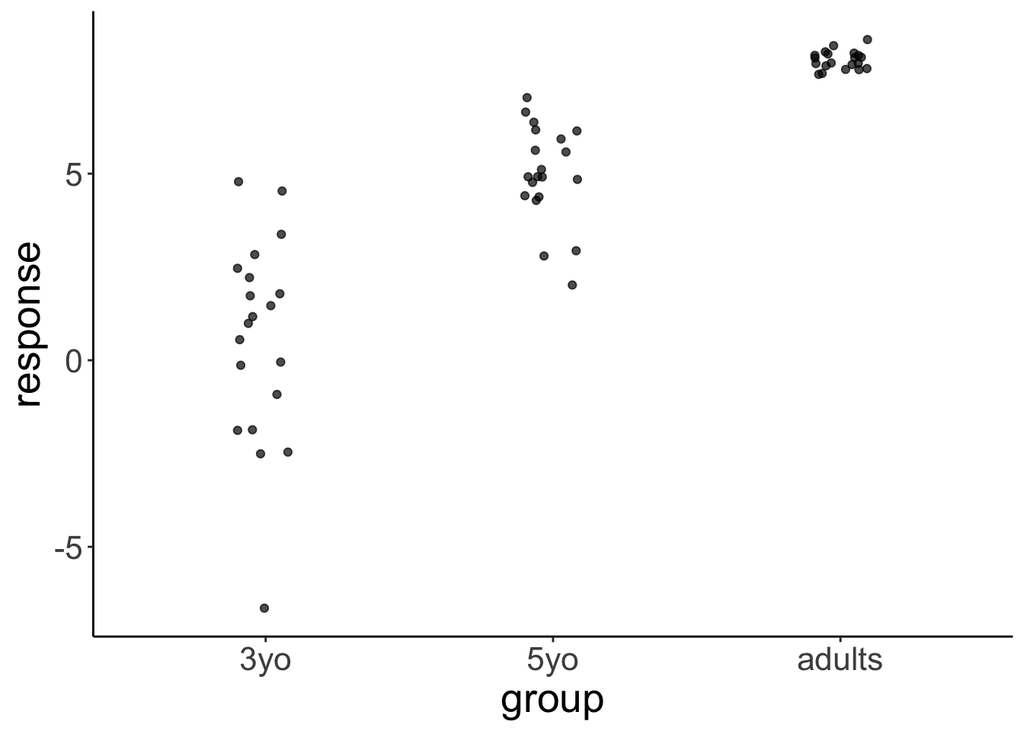

```r
df.variance %>%
  ggplot(aes(x = group, y = response)) +
  geom_jitter(height = 0,
              width = 0.1,
              alpha = 0.7)
```

### 24.4.2 Frequentist analysis

#### 24.4.2.1 Fit the model

```r
fit.lm_variance = lm(formula = response ~ 1 + group,
                     data = df.variance)

fit.lm_variance %>%
  summary()
```

```
Call:
lm(formula = response ~ 1 + group, data = df.variance)

Residuals:
    Min      1Q  Median      3Q     Max
-7.2157 -0.3613  0.0200  0.7001  4.2143

Coefficients:
            Estimate Std. Error t value Pr(>|t|)
(Intercept)   0.5716     0.3931   1.454    0.151
group5yo      4.4187     0.5560   7.948  8.4e-11 ***
groupadults   7.4701     0.5560  13.436  < 2e-16 ***
---
Signif. codes:  0 '***' 0.001 '**' 0.01 '*' 0.05 '.' 0.1 ' ' 1

Residual standard error: 1.758 on 57 degrees of freedom
Multiple R-squared:  0.762, Adjusted R-squared:  0.7537
F-statistic: 91.27 on 2 and 57 DF,  p-value: < 2.2e-16
```

```r
fit.lm_variance %>%
  glance()
```

```
# A tibble: 1 × 12
  r.squared adj.r.squared sigma statistic  p.value    df logLik   AIC   BIC
      <dbl>         <dbl> <dbl>     <dbl>    <dbl> <dbl>  <dbl> <dbl> <dbl>
1     0.762         0.754  1.76      91.3 1.70e-18     2  -117.  243.  251.
# ℹ 3 more variables: deviance <dbl>, df.residual <int>, nobs <int>
```

#### 24.4.2.2 Visualize the model predictions

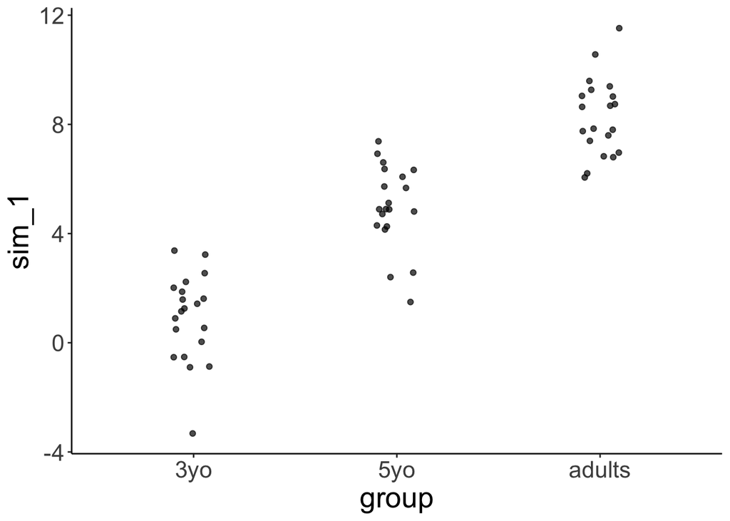

```r
set.seed(1)

fit.lm_variance %>%
  simulate() %>%
  bind_cols(df.variance) %>%
  ggplot(aes(x = group, y = sim_1)) +
  geom_jitter(height = 0,
              width = 0.1,
              alpha = 0.7)
```

Notice how the model predicts that the variance is equal for each group.

### 24.4.3 Bayesian analysis

While frequentist models (such as a linear regression) assume equality of variance, Bayesian models afford us with the flexibility of inferring both the parameter estimates of the groups (i.e. the means and differences between the means), as well as the variances.

#### 24.4.3.1 Fit the model

We define a multivariate model which tries to fit both the `response` as well as the variance `sigma`:

```r
fit.brm_variance = brm(formula = bf(response ~ group,
                                    sigma ~ group),
                       data = df.variance,
                       file = "cache/brm_variance",
                       seed = 1)

summary(fit.brm_variance)
```

```
 Family: gaussian
  Links: mu = identity; sigma = log
Formula: response ~ group
         sigma ~ group
   Data: df.variance (Number of observations: 60)
  Draws: 4 chains, each with iter = 2000; warmup = 1000; thin = 1;
         total post-warmup draws = 4000

Regression Coefficients:
                  Estimate Est.Error l-95% CI u-95% CI Rhat Bulk_ESS Tail_ESS
Intercept            -0.01      0.73    -1.41     1.51 1.01     1107     1072
sigma_Intercept       1.15      0.17     0.85     1.51 1.00     1991     1922
group5yo              5.18      0.77     3.60     6.65 1.00     1253     1327
groupadults           7.98      0.74     6.47     9.37 1.01     1110     1079
sigma_group5yo       -1.05      0.24    -1.51    -0.57 1.00     2249     2420
sigma_groupadults    -2.19      0.24    -2.66    -1.74 1.00     2171     2427

Draws were sampled using sampling(NUTS). For each parameter, Bulk_ESS
and Tail_ESS are effective sample size measures, and Rhat is the potential
scale reduction factor on split chains (at convergence, Rhat = 1).
```

Notice that sigma is on the log scale. To get the standard deviations, we have to exponentiate the predictors, like so:

```r
fit.brm_variance %>%
  tidy(parameters = "^b_") %>%
  filter(str_detect(term, "sigma")) %>%
  select(term, estimate) %>%
  mutate(term = str_remove(term, "b_sigma_")) %>%
  pivot_wider(names_from = term,
              values_from = estimate) %>%
  clean_names() %>%
  mutate(across(-intercept, ~ exp(. + intercept))) %>%
  mutate(intercept = exp(intercept))
```

```
# A tibble: 1 × 3
  intercept group5yo groupadults
      <dbl>    <dbl>       <dbl>
1      3.16     1.10       0.352
```

#### 24.4.3.2 Visualize the model predictions

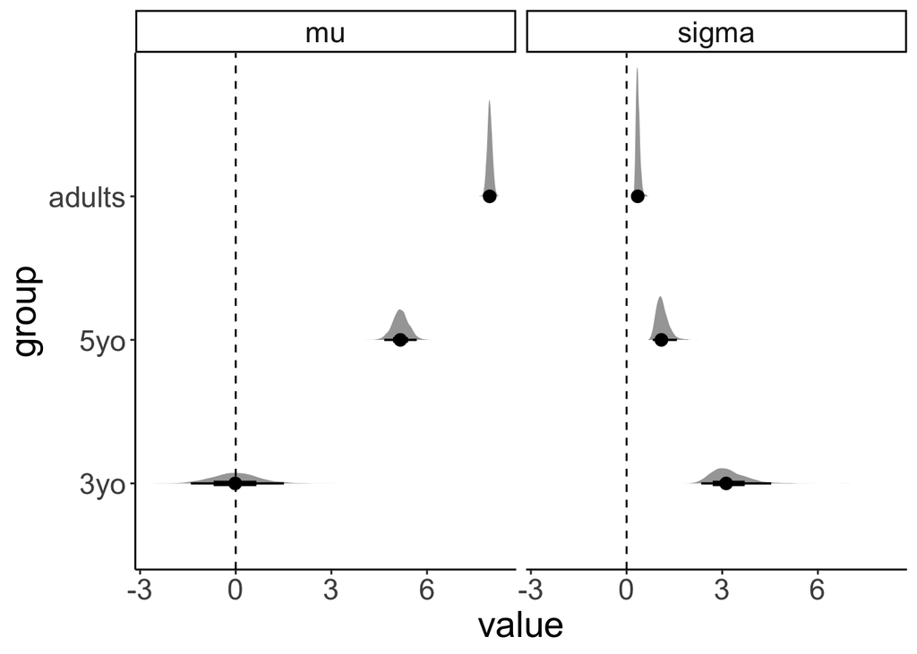

```r
df.variance %>%
  expand(group) %>%
  add_epred_draws(object = fit.brm_variance,
                  dpar = TRUE ) %>%
  select(group,
         .row,
         .draw,
         posterior = .epred,
         mu,
         sigma) %>%
  pivot_longer(cols = c(mu, sigma),
               names_to = "index",
               values_to = "value") %>%
  ggplot(aes(x = value, y = group)) +
  stat_halfeye() +
  geom_vline(xintercept = 0,
             linetype = "dashed") +
  facet_grid(cols = vars(index))
```

This plot shows what the posterior looks like for both mu (the inferred means), and for sigma (the inferred variances) for the different groups.

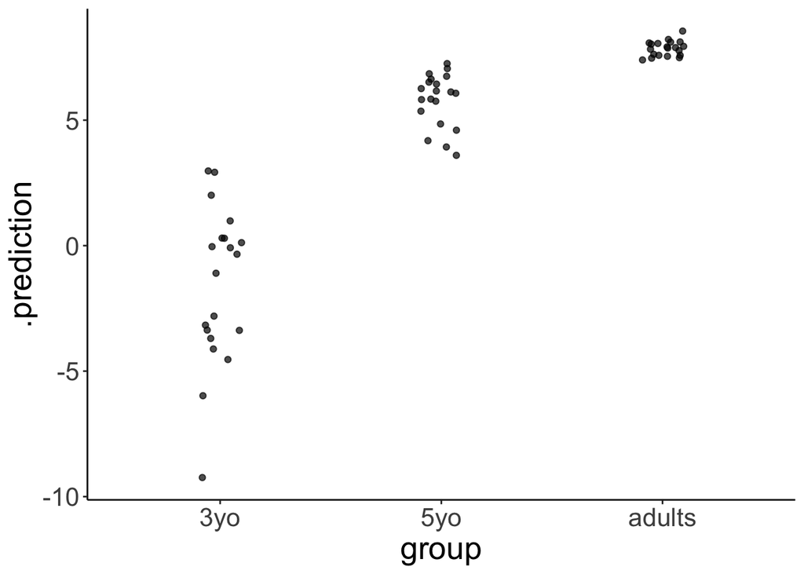

```r
set.seed(1)

df.variance %>%
  add_predicted_draws(object = fit.brm_variance,
                      ndraws = 1) %>%
  ggplot(aes(x = group, y = .prediction)) +
  geom_jitter(height = 0,
              width = 0.1,
              alpha = 0.7)
```

## 24.5 Zero-one inflated beta binomial model

See this [blog post](https://mvuorre.github.io/posts/2019-02-18-analyze-analog-scale-ratings-with-zero-one-inflated-beta-models/).

## 24.6 Ordinal regression

Check out the following two papers:

- Liddell and Kruschke (2018)
- Bürkner and Vuorre (2019)

Let’s read in some movie ratings:

```r
df.movies = read_csv(file = "data/MoviesData.csv")

df.movies = df.movies %>%
  pivot_longer(cols = n1:n5,
               names_to = "stars",
               values_to = "rating") %>%
  mutate(stars = str_remove(stars,"n"),
         stars = as.numeric(stars))

df.movies = df.movies %>%
  uncount(weights = rating) %>%
  mutate(id = as.factor(ID)) %>%
  filter(ID <= 6)
```

### 24.6.1 Ordinal regression (assuming equal variance)

#### 24.6.1.1 Fit the model

```r
fit.brm_ordinal = brm(formula = stars ~ 1 + id,
                      family = cumulative(link = "probit"),
                      data = df.movies,
                      file = "cache/brm_ordinal",
                      seed = 1)

summary(fit.brm_ordinal)
```

```
 Family: cumulative
  Links: mu = probit; disc = identity
Formula: stars ~ 1 + id
   Data: df.movies (Number of observations: 21708)
  Draws: 4 chains, each with iter = 2000; warmup = 1000; thin = 1;
         total post-warmup draws = 4000

Regression Coefficients:
             Estimate Est.Error l-95% CI u-95% CI Rhat Bulk_ESS Tail_ESS
Intercept[1]    -1.23      0.04    -1.30    -1.15 1.00     1833     2517
Intercept[2]    -0.91      0.04    -0.98    -0.83 1.00     1776     2348
Intercept[3]    -0.44      0.04    -0.52    -0.36 1.00     1757     2360
Intercept[4]     0.32      0.04     0.25     0.40 1.00     1767     2188
id2              0.84      0.06     0.72     0.96 1.00     2480     2627
id3              0.22      0.06     0.11     0.33 1.00     2288     2687
id4              0.33      0.04     0.24     0.41 1.00     1855     2355
id5              0.44      0.05     0.34     0.54 1.00     2159     2289
id6              0.75      0.04     0.67     0.83 1.00     1774     2252

Further Distributional Parameters:
     Estimate Est.Error l-95% CI u-95% CI Rhat Bulk_ESS Tail_ESS
disc     1.00      0.00     1.00     1.00   NA       NA       NA

Draws were sampled using sampling(NUTS). For each parameter, Bulk_ESS
and Tail_ESS are effective sample size measures, and Rhat is the potential
scale reduction factor on split chains (at convergence, Rhat = 1).
```

#### 24.6.1.2 Visualizations

##### 24.6.1.2.1 Model parameters

The model infers the thresholds and the means of the Gaussian distributions in latent space.

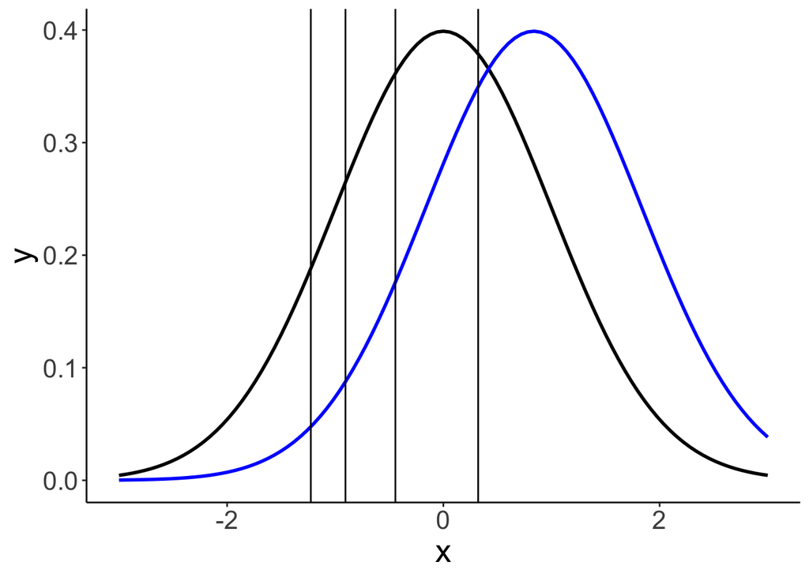

```r
df.params = fit.brm_ordinal %>%
  parameters(centrality = "mean") %>%
  as_tibble() %>%
  clean_names() %>%
  select(term = parameter, estimate = mean)

ggplot(data = tibble(x = c(-3, 3)),
       mapping = aes(x = x)) +
  stat_function(fun = ~ dnorm(.),
                size = 1,
                color = "black") +
  stat_function(fun = ~ dnorm(., mean = df.params %>%
                                filter(str_detect(term, "id2")) %>%
                                pull(estimate)),
                size = 1,
                color = "blue") +
  geom_vline(xintercept = df.params %>%
               filter(str_detect(term, "Intercept")) %>%
               pull(estimate))
```

##### 24.6.1.2.2 MCMC inference

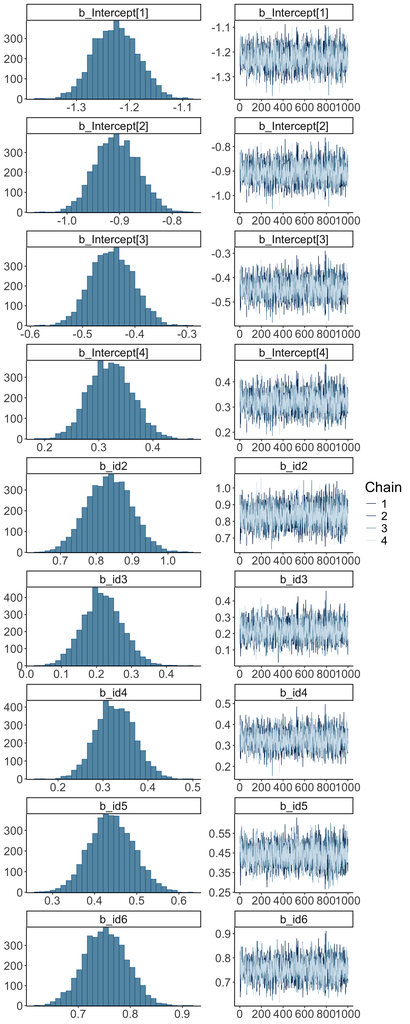

```r
fit.brm_ordinal %>%
  plot(nvariables = 9,
       variable = "^b_",
       regex = T)
```

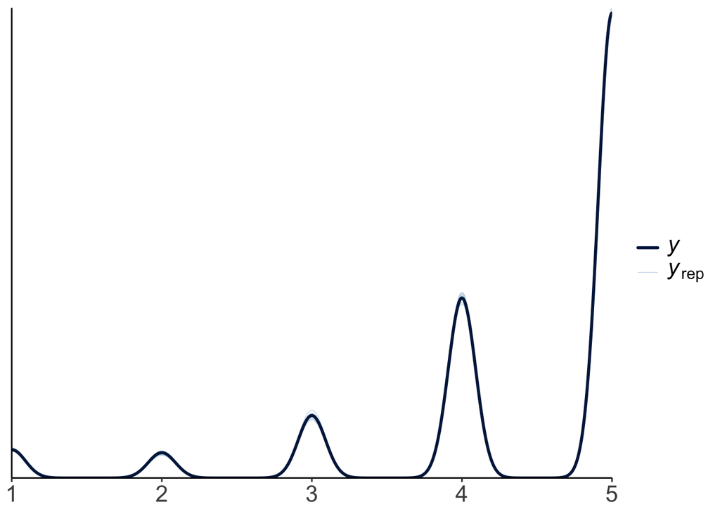

```r
fit.brm_ordinal %>%
  pp_check(ndraws = 20)
```

##### 24.6.1.2.3 Model predictions

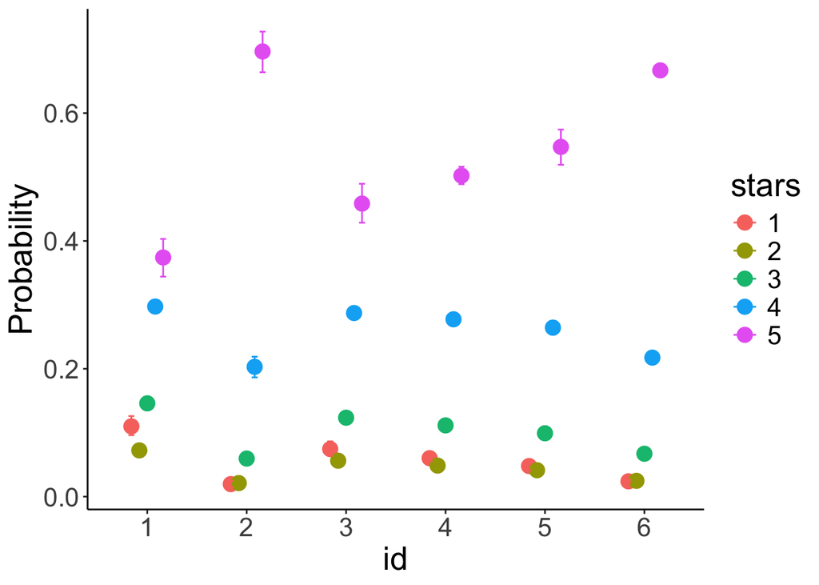

```r
conditional_effects(fit.brm_ordinal,
                    effects = "id",
                    categorical = T)
```

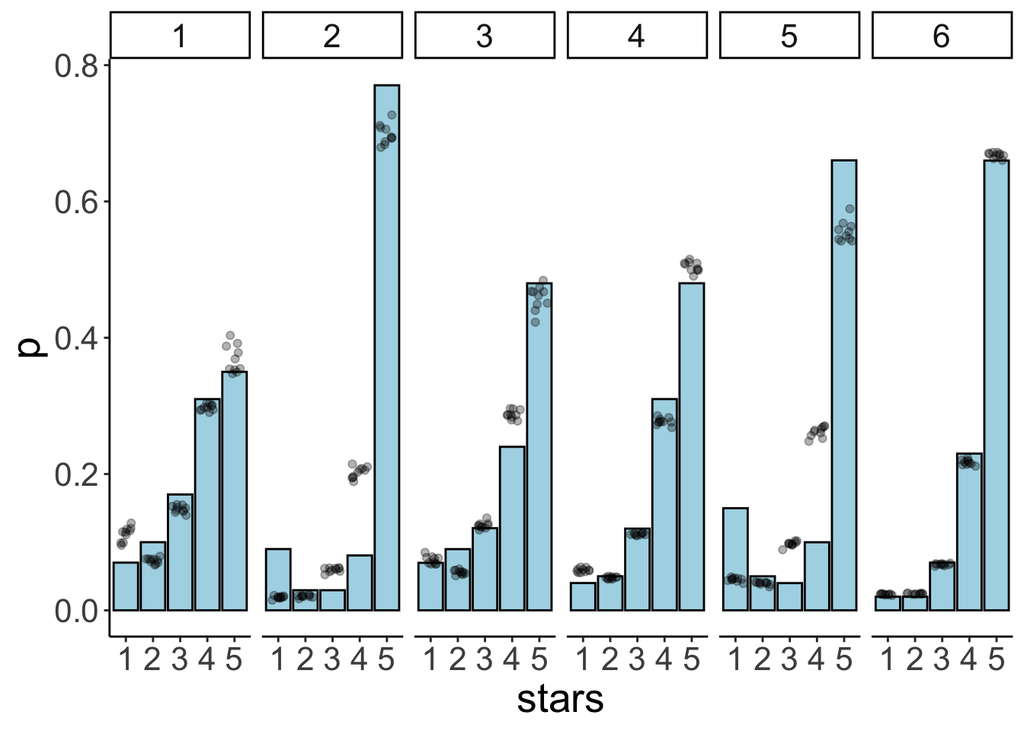

```r
df.model = add_epred_draws(newdata = expand_grid(id = 1:6),
                           object = fit.brm_ordinal,
                           ndraws = 10)

df.plot = df.movies %>%
  count(id, stars) %>%
  group_by(id) %>%
  mutate(p = n / sum(n)) %>%
  mutate(stars = as.factor(stars))

ggplot(data = df.plot,
       mapping = aes(x = stars,
                     y = p)) +
  geom_col(color = "black",
           fill = "lightblue") +
  geom_point(data = df.model,
             mapping = aes(x = .category,
                           y = .epred),
             alpha = 0.3,
             position = position_jitter(width = 0.3)) +
  facet_wrap(~id, ncol = 6)
```

### 24.6.2 Gaussian regression (assuming equal variance)

#### 24.6.2.1 Fit the model

```r
fit.brm_metric = brm(formula = stars ~ 1 + id,
                     data = df.movies,
                     file = "cache/brm_metric",
                     seed = 1)

summary(fit.brm_metric)
```

```
 Family: gaussian
  Links: mu = identity; sigma = identity
Formula: stars ~ 1 + id
   Data: df.movies (Number of observations: 21708)
  Draws: 4 chains, each with iter = 2000; warmup = 1000; thin = 1;
         total post-warmup draws = 4000

Regression Coefficients:
          Estimate Est.Error l-95% CI u-95% CI Rhat Bulk_ESS Tail_ESS
Intercept     3.77      0.04     3.70     3.84 1.00     1203     1621
id2           0.64      0.05     0.54     0.75 1.00     1605     2335
id3           0.20      0.05     0.10     0.30 1.00     1559     2147
id4           0.37      0.04     0.29     0.45 1.00     1267     1862
id5           0.30      0.05     0.21     0.40 1.00     1442     2154
id6           0.72      0.04     0.65     0.79 1.00     1205     1720

Further Distributional Parameters:
      Estimate Est.Error l-95% CI u-95% CI Rhat Bulk_ESS Tail_ESS
sigma     1.00      0.00     0.99     1.01 1.00     3300     2723

Draws were sampled using sampling(NUTS). For each parameter, Bulk_ESS
and Tail_ESS are effective sample size measures, and Rhat is the potential
scale reduction factor on split chains (at convergence, Rhat = 1).
```

#### 24.6.2.2 Visualizations

##### 24.6.2.2.1 Model predictions

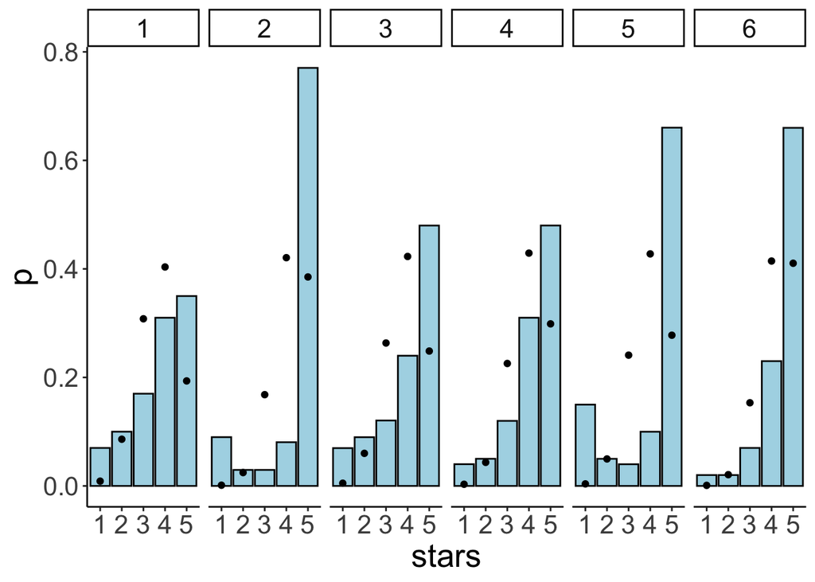

```r
# get the predictions for each value of the Likert scale
df.model = fit.brm_metric %>%
  parameters(centrality = "mean") %>%
  as_tibble() %>%
  select(term = Parameter, estimate = Mean) %>%
  mutate(term = str_remove(term, "b_")) %>%
  pivot_wider(names_from = term,
              values_from = estimate) %>%
  clean_names() %>%
  mutate(across(.cols = id2:id6,
                .fns = ~ . + intercept)) %>%
  rename_with(.fn = ~ c(str_c("mu_", 1:6), "sigma")) %>%
  pivot_longer(cols = contains("mu"),
               names_to = c("parameter", "movie"),
               names_sep = "_",
               values_to = "value") %>%
  pivot_wider(names_from = parameter,
              values_from = value) %>%
  mutate(data = map2(.x = mu,
                     .y = sigma,
                     .f = ~ tibble(x = 1:5,
                                   y  = dnorm(x,
                                              mean = .x,
                                              sd = .y)))) %>%
  select(movie, data) %>%
  unnest(c(data)) %>%
  group_by(movie) %>%
  mutate(y = y/sum(y)) %>%
  ungroup() %>%
  rename(id = movie)

# visualize the predictions
df.plot = df.movies %>%
  count(id, stars) %>%
  group_by(id) %>%
  mutate(p = n / sum(n)) %>%
  mutate(stars = as.factor(stars))

ggplot(data = df.plot,
       mapping = aes(x = stars,
                     y = p)) +
  geom_col(color = "black",
           fill = "lightblue") +
  geom_point(data = df.model,
            mapping = aes(x = x,
                          y = y)) +
  facet_wrap(~id, ncol = 6)
```

### 24.6.3 Oridnal regression (unequal variance)

#### 24.6.3.1 Fit the model

```r
fit.brm_ordinal_variance = brm(formula = bf(stars ~ 1 + id) +
                                 lf(disc ~ 0 + id, cmc = FALSE),
                               family = cumulative(link = "probit"),
                               data = df.movies,
                               file = "cache/brm_ordinal_variance",
                               seed = 1)

summary(fit.brm_ordinal_variance)
```

```
 Family: cumulative
  Links: mu = probit; disc = log
Formula: stars ~ 1 + id
         disc ~ 0 + id
   Data: df.movies (Number of observations: 21708)
  Draws: 4 chains, each with iter = 2000; warmup = 1000; thin = 1;
         total post-warmup draws = 4000

Regression Coefficients:
             Estimate Est.Error l-95% CI u-95% CI Rhat Bulk_ESS Tail_ESS
Intercept[1]    -1.41      0.06    -1.53    -1.29 1.00     1564     2050
Intercept[2]    -1.00      0.05    -1.10    -0.90 1.00     2110     2332
Intercept[3]    -0.46      0.04    -0.54    -0.38 1.00     3122     2887
Intercept[4]     0.41      0.05     0.32     0.51 1.00     1512     2268
id2              2.71      0.31     2.14     3.39 1.00     1653     1976
id3              0.33      0.07     0.20     0.47 1.00     1978     2815
id4              0.36      0.05     0.26     0.46 1.00     1667     2437
id5              1.64      0.17     1.32     1.98 1.00     1712     2327
id6              0.86      0.06     0.74     0.98 1.00     1212     1999
disc_id2        -1.12      0.10    -1.31    -0.94 1.00     1724     1915
disc_id3        -0.23      0.06    -0.34    -0.11 1.00     1418     1950
disc_id4        -0.01      0.04    -0.09     0.08 1.00     1050     1408
disc_id5        -1.09      0.07    -1.22    -0.95 1.00     1524     2316
disc_id6        -0.07      0.04    -0.15     0.01 1.00     1004     1399

Draws were sampled using sampling(NUTS). For each parameter, Bulk_ESS
and Tail_ESS are effective sample size measures, and Rhat is the potential
scale reduction factor on split chains (at convergence, Rhat = 1).
```

#### 24.6.3.2 Visualizations

##### 24.6.3.2.1 Model parameters

```r
df.params = fit.brm_ordinal_variance %>%
  tidy(parameters = "^b_") %>%
  select(term, estimate) %>%
  mutate(term = str_remove(term, "b_"))
```

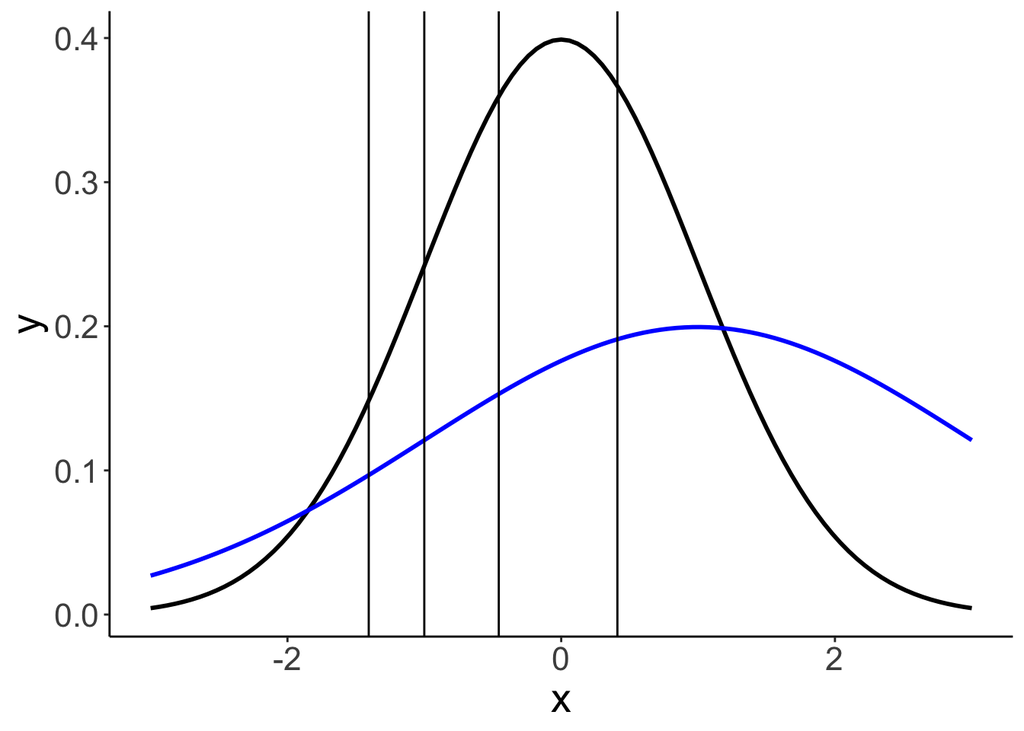

```r
ggplot(data = tibble(x = c(-3, 3)),
       mapping = aes(x = x)) +
  stat_function(fun = ~ dnorm(.),
                size = 1,
                color = "black") +
  stat_function(fun = ~ dnorm(.,
                              mean = 1,
                              sd = 2),
                size = 1,
                color = "blue") +
  geom_vline(xintercept = df.params %>%
               filter(str_detect(term, "Intercept")) %>%
               pull(estimate))
```

##### 24.6.3.2.2 Model predictions

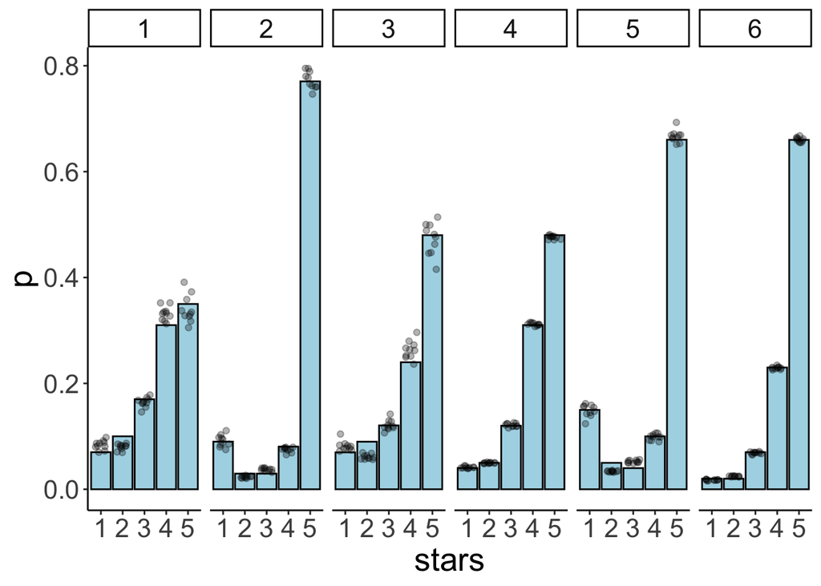

```r
df.model = add_epred_draws(newdata = expand_grid(id = 1:6),
                           object = fit.brm_ordinal_variance,
                           ndraws = 10)

df.plot = df.movies %>%
  count(id, stars) %>%
  group_by(id) %>%
  mutate(p = n / sum(n)) %>%
  mutate(stars = as.factor(stars))

ggplot(data = df.plot,
       mapping = aes(x = stars,
                     y = p)) +
  geom_col(color = "black",
           fill = "lightblue") +
  geom_point(data = df.model,
             mapping = aes(x = .category,
                           y = .epred),
             alpha = 0.3,
             position = position_jitter(width = 0.3)) +
  facet_wrap(~id, ncol = 6)
```

### 24.6.4 Gaussian regression (unequal variance)

#### 24.6.4.1 Fit the model

```r
fit.brm_metric_variance = brm(formula = bf(stars ~ 1 + id,
                            sigma ~ 1 + id),
               data = df.movies,
               file = "cache/brm_metric_variance",
               seed = 1)

summary(fit.brm_metric_variance)
```

```
 Family: gaussian
  Links: mu = identity; sigma = log
Formula: stars ~ 1 + id
         sigma ~ 1 + id
   Data: df.movies (Number of observations: 21708)
  Draws: 4 chains, each with iter = 2000; warmup = 1000; thin = 1;
         total post-warmup draws = 4000

Regression Coefficients:
                Estimate Est.Error l-95% CI u-95% CI Rhat Bulk_ESS Tail_ESS
Intercept           3.77      0.05     3.68     3.86 1.00     1429     1985
sigma_Intercept     0.20      0.03     0.15     0.25 1.00     1530     1891
id2                 0.64      0.07     0.51     0.77 1.00     1888     2421
id3                 0.20      0.06     0.07     0.33 1.00     1866     2185
id4                 0.37      0.05     0.27     0.47 1.00     1500     2009
id5                 0.30      0.06     0.18     0.43 1.00     1905     2216
id6                 0.72      0.05     0.63     0.82 1.00     1416     2072
sigma_id2           0.02      0.04    -0.05     0.09 1.00     2095     2789
sigma_id3           0.03      0.04    -0.04     0.10 1.00     1874     2556
sigma_id4          -0.14      0.03    -0.19    -0.08 1.00     1669     2129
sigma_id5           0.20      0.03     0.14     0.27 1.00     1864     2203
sigma_id6          -0.35      0.03    -0.40    -0.30 1.00     1601     2009

Draws were sampled using sampling(NUTS). For each parameter, Bulk_ESS
and Tail_ESS are effective sample size measures, and Rhat is the potential
scale reduction factor on split chains (at convergence, Rhat = 1).
```

#### 24.6.4.2 Visualizations

##### 24.6.4.2.1 Model predictions

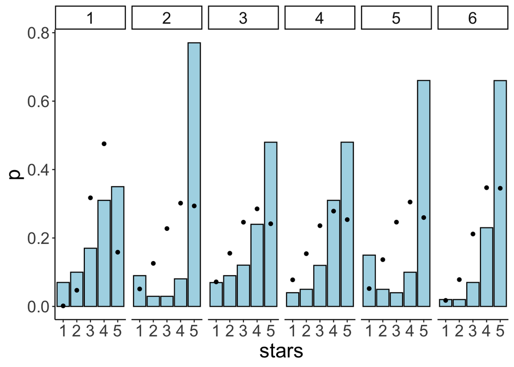

```r
df.model = fit.brm_metric_variance %>%
  tidy(parameters = "^b_") %>%
  select(term, estimate) %>%
  mutate(term = str_remove(term, "b_")) %>%
  pivot_wider(names_from = term,
              values_from = estimate) %>%
  clean_names() %>%
  mutate(across(.cols = c(id2:id6),
                .fns = ~ . + intercept)) %>%
  mutate(across(.cols = contains("sigma"),
                .fns = ~ 1/exp(.))) %>%
  mutate(across(.cols = c(sigma_id2:sigma_id5),
                .fns = ~ . + sigma_intercept)) %>%
  set_names(c("mu_1", "sigma_1", str_c("mu_", 2:6), str_c("sigma_", 2:6))) %>%
  pivot_longer(cols = everything(),
               names_to = c("parameter", "movie"),
               names_sep = "_",
               values_to = "value") %>%
  pivot_wider(names_from = parameter,
              values_from = value) %>%
  mutate(data = map2(.x = mu,
                     .y = sigma,
                     .f = ~ tibble(x = 1:5,
                                   y  = dnorm(x,
                                              mean = .x,
                                              sd = .y)))) %>%
  select(movie, data) %>%
  unnest(c(data)) %>%
  group_by(movie) %>%
  mutate(y = y/sum(y)) %>%
  ungroup() %>%
  rename(id = movie)
df.plot = df.movies %>%
  count(id, stars) %>%
  group_by(id) %>%
  mutate(p = n / sum(n)) %>%
  mutate(stars = as.factor(stars))

ggplot(data = df.plot,
       mapping = aes(x = stars,
                     y = p)) +
  geom_col(color = "black",
           fill = "lightblue") +
  geom_point(data = df.model,
             mapping = aes(x = x,
                           y = y)) +
  facet_wrap(~id, ncol = 6)
```

### 24.6.5 Model comparison

```r
# currently not working

# ordinal regression with equal variance
fit.brm_ordinal = add_criterion(fit.brm_ordinal,
                                criterion = "loo",
                                file = "cache/brm_ordinal")

# Gaussian regression with equal variance
fit.brm_ordinal_variance = add_criterion(fit.brm_ordinal_variance,
                                         criterion = "loo",
                                         file = "cache/brm_ordinal_variance")

loo_compare(fit.brm_ordinal, fit.brm_ordinal_variance)
```

## 24.7 Additional resources

- [Tutorial on visualizing brms posteriors with tidybayes](https://mjskay.github.io/tidybayes/articles/tidy-brms.html)
- [Hypothetical outcome plots](https://mucollective.northwestern.edu/files/2018-HOPsTrends-InfoVis.pdf)
- [Visual MCMC diagnostics](https://cran.r-project.org/web/packages/bayesplot/vignettes/visual-mcmc-diagnostics.html#general-mcmc-diagnostics)
- [Visualiztion of different MCMC algorithms](https://chi-feng.github.io/mcmc-demo/)
- [Frequentist equivalence test](https://www.carlislerainey.com/blog/2023-08-18-equivalence-tests/?s=09)

For additional resources, I highly recommend the brms and tidyverse implementations of the Statistical rethinking book (McElreath 2020), as well as of the Doing Bayesian Data analysis book (Kruschke 2014), by Solomon Kurz (Kurz 2020, 2022).

Bürkner, Paul-Christian, and Matti Vuorre. 2019. “Ordinal Regression Models in Psychology: A Tutorial.” *Advances in Methods and Practices in Psychological Science*, 25.

Kruschke, John. 2014. “Doing Bayesian Data Analysis: A Tutorial with r, JAGS, and Stan.”

Kurz, A. Solomon. 2020. *ASKurz/Statistical_Rethinking_with_brms_ggplot2_an d_the_tidyverse: Correct multinomial and Gaussian process models*. Zenodo. https://doi.org/10.5281/zenodo.4080013.

———. 2022. *Doing Bayesian Data Analysis in Brms and the Tidyverse*. Version 1.0.0. https://bookdown.org/content/3686/.

Liddell, Torrin M., and John K. Kruschke. 2018. “Analyzing Ordinal Data with Metric Models: What Could Possibly Go Wrong?” *Journal of Experimental Social Psychology* 79 (November): 328–48. https://doi.org/10.1016/j.jesp.2018.08.009.

McElreath, Richard. 2020. *Statistical Rethinking: A Bayesian Course with Examples in r and Stan*. Chapman; Hall/CRC.

Wagenmakers, Eric-Jan, Tom Lodewyckx, Himanshu Kuriyal, and Raoul Grasman. 2010. “Bayesian Hypothesis Testing for Psychologists: A Tutorial on the Savage Method.” *Cognitive Psychology* 60 (3): 158–89. https://doi.org/10.1016/j.cogpsych.2009.12.001.